# Qploidy2 and nQuack Integration Tutorial

Large-scale copy number estimation in alfalfa mapping population using nQuack EM-based BAF model selection

Breeding Insight

2026-10-27

# 1 Introduction

This tutorial demonstrates how to run Qploidy2’s copy number estimation using the **nQuack EM-based BAF model selection** route. It uses the same alfalfa mapping population dataset as the main Qploidy2 tutorial and assumes that you have already completed the **Standardization** step described there (`standardize()`).

> **Important**: The nQuack route requires allele read counts (`X`, `Y`, `R` columns) and is therefore **exclusive to sequencing-based data** (WGS, targeted sequencing such as DArTag/GTseq/AgriSeq, etc.). It cannot be used with intensity-based genotyping arrays (Axiom, Illumina), because arrays do not produce read counts. For array data, use `hmm_estimate_CN()` (the grid-based BAF model selection route) instead.

## 1.1 `hmm_estimate_CN_nQuack()`: a self-contained nQuack route

The nQuack integration is a separate, self-contained function, `hmm_estimate_CN_nQuack()`. It implements the same HMM structure as `hmm_estimate_CN` but using nQuack EM models to estimate both the overall sample ploidy estimate and per-window BAF likelihoods/dosage calling. Because nQuack only models copy-number states 2 through 6, `cn_grid` must be a subset of `2:6`; use `hmm_estimate_CN()` instead for CN=0/1/LOH detection or ploidies outside 2:6.

Its signature mirrors `hmm_estimate_CN()` for the shared windowing/HMM arguments (`cn_grid`, `chr`, `segment_zscore`, `exp_ploidy`, etc.), plus two arguments specific to nQuack:

[output not shown]

`hmm_estimate_CN_multi()` auto-detects which function to run per sample: if either `nQuack_cores` or `nQuack_dists` is passed via `...`, it dispatches to `hmm_estimate_CN_nQuack()`; otherwise it runs `hmm_estimate_CN()`.

`nQuack` must be installed before using this route:

```r
remotes::install_github("mgaynor1/nQuack@updateGL")
```

For full details on the grid-based route, see the Qploidy2 alfalfa tutorial. For background on nQuack itself, see [Gaynor et al. (2024)](https://doi.org/10.1002/aps3.11606) and the [nQuack vignettes](https://mlgaynor.com/nQuack/).

# 2 Data Preparation

Follow Steps 1–4 of the main tutorial to obtain the standardized object. The code below reproduces those steps for completeness.

```r
library(Qploidy2)
```

## 2.1 Download the alfalfa dataset

```r
vcf_path_web <- "https://github.com/Breeding-Insight/BIGapp-PanelHub/raw/refs/heads/long_seq/alfalfa/GenoBrew_example/alfalfa_F1_marker_panel_dataset_publicly_available.vcf.gz"
download.file(vcf_path_web,
              destfile = "alfalfa_F1_marker_panel_dataset_publicly_available.vcf.gz")
vcf_path_local <- "alfalfa_F1_marker_panel_dataset_publicly_available.vcf.gz"
```

## 2.2 Read input files

```r
data     <- qploidy_read_vcf(vcf_path_local)
genos    <- qploidy_read_vcf(vcf_path_local, geno     = TRUE)
geno.pos <- qploidy_read_vcf(vcf_path_local, geno.pos = TRUE)
```

## 2.3 Standardize

The nQuack integration requires the columns `X` (reference allele count), `Y` (alternative allele count), and `R` (total depth) that are present in the `$data` slot of the standardized object. Make sure your standardization step preserves them (the default `standardize()` call does).

```r
qploidy_standardization <- standardize(
  data                   = data,
  genos                  = genos,
  geno.pos               = geno.pos,
  ploidy.standardization = 4,
  threshold.n.clusters   = 4,
  threshold.missing.geno = 0.9,
  min.depth              = 30,
  max.depth              = 600,
  n.cores                = 2,
  out_filename           = "standardization.tsv.gz",
  verbose                = TRUE
)
```

If you already have the standardized file from the main tutorial, reload it:

```r
qploidy_standardization <- read_qploidy_standardization("standardization.tsv.gz")
```

# 3 Export nQuack input format from standardized BAF

`hmm_estimate_CN_nQuack()` builds the nQuack input matrix automatically (see the next section). If you instead want to inspect the data nQuack sees, or fit `quackNormal()`, `quackBeta()`, or `quackBetaBinom()` yourself outside of Qploidy2’s HMM, use `convert2nQuack()` to convert the standardized object into the list-of-matrices format these functions expect — one matrix per sample.

```r
nquack_input <- convert2nQuack(
  qploidy_standardization_object = qploidy_standardization,
  min_depth              = 10,
  seed                   = 123
)

length(nquack_input)
```

```
## [1] 185
```

```r
head(nquack_input[[1]])
```

```
##        R allele
## [1,] 111     31
## [2,] 100     47
## [3,] 182    136
## [4,] 320    236
## [5,] 102     55
## [6,] 583    292
```

By default (`from_standardized_baf = TRUE`), `convert2nQuack()` derives the allele counts fed to nQuack from the **standardization-corrected** `baf` column rather than the raw `X`/`Y` read counts. For each retained heterozygous site it inverts the standardized BAF back into reference/alternative counts:

- `alt_count <- round(baf * R)`
- `ref_count <- R - alt_count`

and then randomly keeps one of the two (reference or alternative) with equal probability — the same approach used internally by `hmm_estimate_CN_nQuack()`. This ensures nQuack sees allele frequencies that have already been corrected for marker/assay biases by `standardize()`, which matters most for data where raw `X`/`Y` ratios can be systematically skewed per marker.

If you would rather fit nQuack on the raw, uncorrected allele counts, set `from_standardized_baf = FALSE`:

```r
nquack_input_raw <- convert2nQuack(
  qploidy_standardization_object = qploidy_standardization,
  min_depth              = 10,
  from_standardized_baf  = FALSE
)
```

Each element of the returned list is a two-column integer matrix (one row per qualifying site): column 1 is the total read depth `R`, column 2 is the randomly selected allele count. You can fit any of the nQuack models directly on this output, e.g.:

```r
nQuack::quackBeta(xm = nquack_input[[1]], samplename = names(nquack_input)[1], cores = 1)
```

See `?convert2nQuack` for the full filtering details (homozygous-site removal, minimum depth, genotype dosage filter).

# 4 How nQuack Input Is Built Inside Qploidy2

> **You do not need to prepare nQuack input yourself.** `hmm_estimate_CN_nQuack()` builds the nQuack input matrix automatically from the `$data` slot of your standardized object.

For transparency, here is what happens internally for each sample:

**Step 1 — Discard homozygous markers.** Only markers where the sample is heterozygous are kept. A site is considered heterozygous when its allele ratio is neither 0 (all-reference) nor 1 (all-alternative), and its dosage call (`geno`) is neither 0 (homozygous reference) nor the maximum dosage for the dataset (homozygous alternative). In practice this means markers where the sample carries at least one copy of each allele. Homozygous markers are discarded because their allele frequency provides no information for distinguishing ploidy levels — only heterozygous sites generate the mixture of allele-frequency peaks that nQuack models.

**Step 2 — Remove low-coverage sites.** Sites with total read depth `R < 10` are discarded. At very low depths, allele counts are too noisy to reliably estimate allele frequencies. The threshold of 10 reads is nQuack’s recommended minimum for meaningful allele-frequency estimation.

**Step 3 — Randomly sample one allele per site.** For each remaining heterozygous site, either the reference (`X`) or the alternative (`Y`) allele count is randomly drawn with equal probability (P = 0.5). This produces a matrix with two columns:

- **column 1**: `R`, the total read depth at that site
- **column 2**: `sampled_count`, the read count for the randomly chosen allele (either the reference count `X` or the alternative count `Y`)

**Step 4 — Fit nQuack models.** The two-column matrix is passed to `quackNormal`, `quackBeta`, and `quackBetaBinom`. Each function fits mixture models for all candidate ploidies (from `cn_grid`, restricted to the range 2–6 supported by nQuack). The model with the lowest BIC across all families and all ploidies is declared the winner, and its ploidy becomes `exp_ploidy` for the HMM.

The random allele sampling in Step 3 means results can vary slightly between runs. Set `set.seed()` before calling `hmm_estimate_CN_nQuack()` for reproducibility.

# 5 BAF Model Selection and HMM: the nQuack Route

## 5.1 Single sample

`hmm_estimate_CN_nQuack()` lets nQuack handle the entire BAF model selection step. By default it only fits the Normal family (fastest option) for each candidate ploidy; set `nQuack_dists = NULL` to also test Beta and Beta-Binomial and pick the best by BIC. Qploidy2 then uses the winning distribution and ploidy to build the HMM emission parameters.

```r
set.seed(42)
res_nq <- hmm_estimate_CN_nQuack(
  qploidy_standarize_result = qploidy_standardization,
  sample_id                 = "J432",
  cn_grid                   = c(2, 3, 4, 5, 6),
  nQuack_cores              = 2,
  nQuack_dists = "normal",
  min_snps_per_window = 50,
  verbose                   = TRUE
)

res_nq
```

```
## hmm_CN result
##   Copy-number grid: 2, 3, 4, 5, 6
##   Expected ploidy: 4
##   Minimum SNPs per window: 50
##   Initial state probabilities (pi0): 0.125, 0.125, 0.5, 0.125, 0.125
##   Estimated z means per CN: -0.116, 0.074, 0.264, 0.459, 0.653
##   Estimated z mean: 0.2645141
##   Estimated z sigma: 0.111
##   BAF Emission distribution: normal-uniform
##   Final log-likelihood: 0
##   Range of CN_call (window-level): 4 - 4
```

Inspect the karyotype:

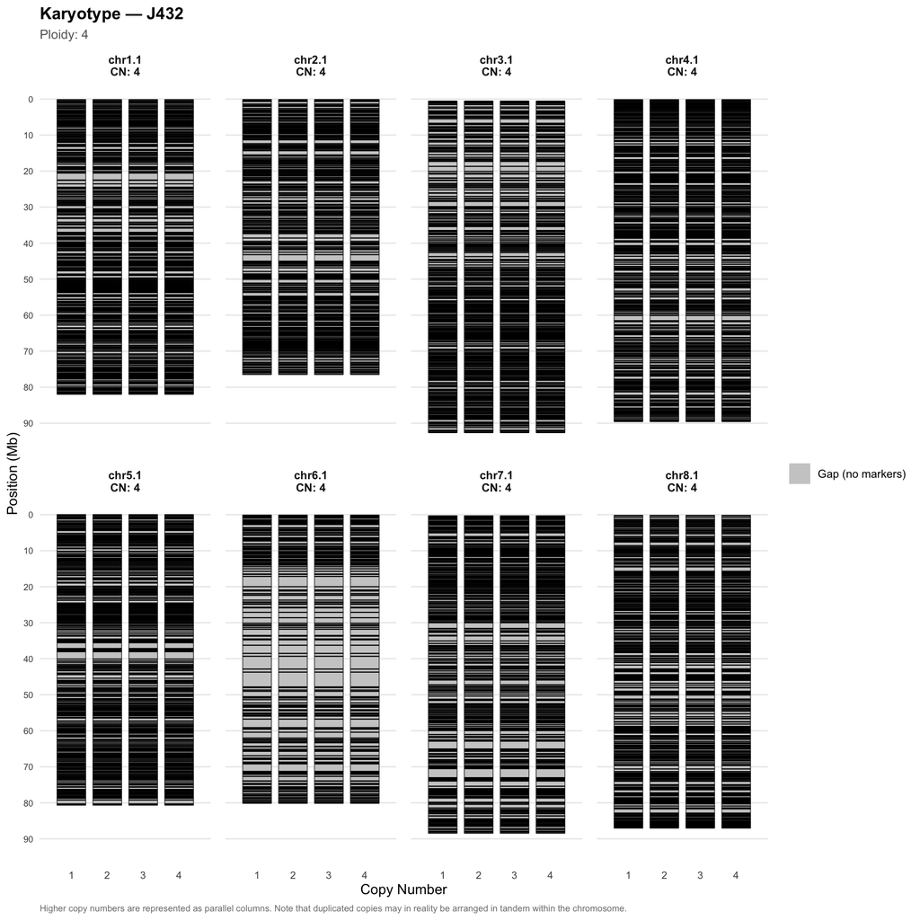

```r
plot_karyotype(res_nq, sample_name = "J432", nrow = 2)
```

Color by HMM posterior confidence:

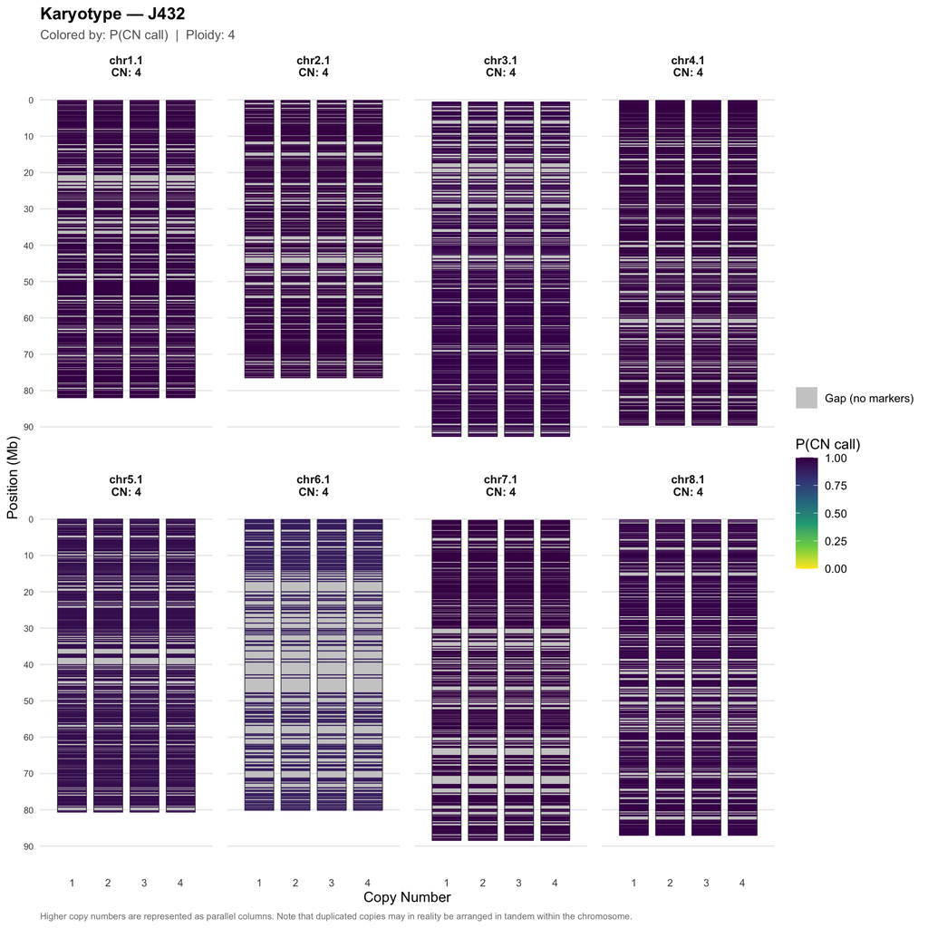

```r
plot_karyotype(res_nq, sample_name = "J432", nrow = 2, color_by = "post_max_CN")
```

Detailed diagnostic track:

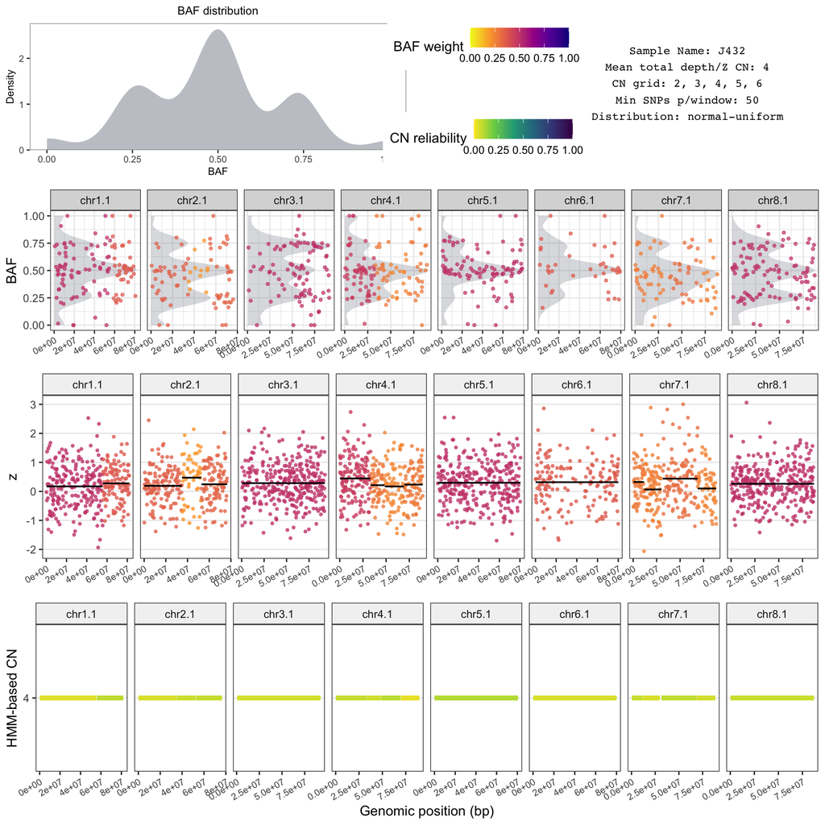

```r
p <- plot_cn_track(hmm_CN      = res_nq,
                   data        = data,
                   geno.pos    = geno.pos,
                   sample_id   = "J432",
                   show_window_lines = FALSE,
                   z_by_mean   = TRUE)
p$arranged
```

## 5.2 Restricting distribution families with `nQuack_dists`

By default, only the Normal family is tested. Set `nQuack_dists = NULL` to test all three families, or pass a subset once you know from a pilot run which families fit your data:

```r
# Test only the Normal family (Normal and Normal+Uniform variants)
res_nq_normal <- hmm_estimate_CN_nQuack(
  qploidy_standarize_result = qploidy_standardization,
  sample_id                 = "J432",
  cn_grid                   = c(2, 3, 4, 5, 6),
  nQuack_dists              = "normal",
  nQuack_cores              = 2
)

# Test Beta and Beta-Binomial only
res_nq_seq <- hmm_estimate_CN_nQuack(
  qploidy_standarize_result = qploidy_standardization,
  sample_id                 = "J432",
  cn_grid                   = c(2, 3, 4, 5, 6),
  nQuack_dists              = c("beta", "beta-binomial"),
  nQuack_cores              = 2
)
```

Valid values for `nQuack_dists`: `"normal"`, `"beta"`, `"beta-binomial"`. Pass a character vector to test multiple families while excluding others.

## 5.3 Multiple samples

Run the nQuack route for all samples in parallel. Because nQuack fits multiple mixture models per sample, this takes longer than the grid route. The two parallelism arguments work at different levels:

- `n_cores`: number of samples processed simultaneously (outer parallelism)
- `nQuack_cores`: number of cores used by nQuack within each sample (inner parallelism)

On most workstations, set `nQuack_cores = 1` and tune `n_cores` to balance memory and CPU usage across samples.

`hmm_estimate_CN_multi()` detects the nQuack route automatically: passing `nQuack_cores` and/or `nQuack_dists` (via `...`) is enough to dispatch each sample to `hmm_estimate_CN_nQuack()` instead of `hmm_estimate_CN()`.

```r
set.seed(42)
multi_esti_nq <- hmm_estimate_CN_multi(
  qploidy_standarize_result = qploidy_standardization,
  sample_ids                = "all",
  n_cores                   = 3,
  cn_grid                   = c(2, 3, 4, 5, 6),
  nQuack_dists              = c("normal"),
  nQuack_cores              = 1
)
```

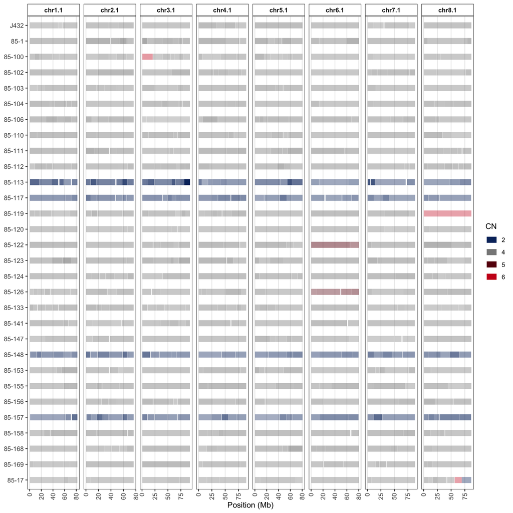

```r
samples <- unique(qploidy_standardization$data$SampleName)
compare_cn_track(hmm_CN          = multi_esti_nq,
                 samples_to_plot = samples[1:30],
                 facet_ncol      = 8)
```

# 6 Comparing Routes: nQuack vs. Grid

For a well-behaved tetraploid dataset the two routes typically agree. The table below summarises their trade-offs:

| Feature | Grid (`hmm_estimate_CN()`) | nQuack (`hmm_estimate_CN_nQuack()`) |
| --- | --- | --- |
| BAF model selection | Grid search over KDE bandwidth | nQuack EM for ploidy + all BAF parameters |
| Speed | Faster | Slower |
| Mixture families tested | Parametric templates | Normal, Beta, Beta-Binomial |
| Data requirement | Ratio/BAF only | Read counts (X, Y, R) |
| CN range | Any (including 0/1/LOH) | 2–6 only |

# 7 Filter, Summarize, and Export

All downstream steps are identical regardless of which route was used. The examples below use the nQuack route results (`multi_esti_nq`).

## 7.1 Filter by quality

```r
multi_esti_nq_filtered <- filter_hmm_CN(multi_esti_nq,
                                        min_CN_reliability = 0.05,
                                        min_post_max       = 0.4)
```

## 7.2 Ploidy type summary

```r
types_df <- count_types(multi_esti_nq_filtered)
types_df
```

```
##
## Sample classification summary
## ====================================================
##   2x  (n = 11)
##     2x - euploid            10
##     2x - segmental          1
##   3x  (n = 7)
##     3x - euploid            2
##     3x - aneuploid          5
##   4x  (n = 161)
##     4x - euploid            137
##     4x - aneuploid          22
##     4x - segmental          2
##   5x  (n = 3)
##     5x - euploid            2
##     5x - aneuploid          1
## ----------------------------------------------------
##   Total euploid              151
##   Total aneuploid            28
##   Total segmental aneuploidy 3
##   Grand total                182
## ====================================================
```

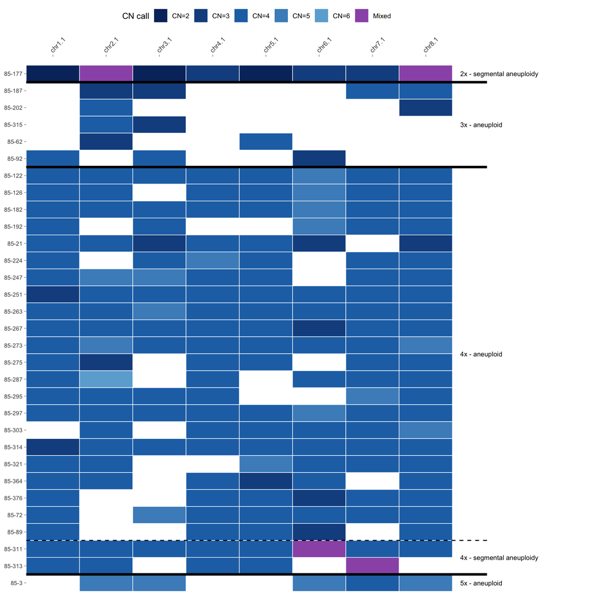

```r
compare_cn_track_summary(
  multi_esti_nq_filtered,
  samples_to_plot = c(types_df$aneuploid, types_df$segmental)
)
```

## 7.3 Per-sample, per-chromosome summaries

```r
summ_chr    <- summarize_cn_mode(multi_esti_nq_filtered, level = "chromosome")
summ_sample <- summarize_cn_mode(multi_esti_nq_filtered, level = "sample")

head(summ_chr)
```

|  | Sample | Chr | CN_mode | mean_max_prob | n_windows |
| --- | --- | --- | --- | --- | --- |
| 1 | 85-1 | chr1.1 | 4 | 0.9611937 | 1 |
| 2 | 85-1 | chr2.1 | 4 | 0.9997398 | 4 |
| 3 | 85-1 | chr3.1 | 4 | 0.9997934 | 7 |
| 4 | 85-1 | chr4.1 | 4 | 0.9967497 | 3 |
| 5 | 85-1 | chr5.1 | 4 | 0.9998093 | 5 |
| 6 | 85-1 | chr6.1 | 4 | 0.9987141 | 3 |

```r
head(summ_sample)
```

|  | Sample | CN_mode | mean_max_prob | n_windows |
| --- | --- | --- | --- | --- |
| 1 | 85-1 | 4 | 0.9950469 | 28 |
| 2 | 85-100 | NA | 0.9917875 | 34 |
| 3 | 85-102 | 4 | 0.9940847 | 21 |
| 4 | 85-103 | 4 | 0.9373534 | 19 |
| 5 | 85-104 | 4 | 0.9920213 | 24 |
| 6 | 85-106 | 4 | 0.9548227 | 29 |

## 7.4 Write results

```r
write_hmm_CN(multi_esti_nq_filtered, prefix = "alfalfa_nQuack")
```

Reload in a later session:

```r
multi_esti_nq_filtered <- read_hmm_CN(
  by_marker_file = "alfalfa_nQuack_by_marker.csv.gz",
  by_window_file = "alfalfa_nQuack_by_window.csv.gz",
  params_file    = "alfalfa_nQuack_params.rds"
)
```

## 7.5 MAPpoly export

```r
for_mappoly <- export_mappoly(multi_esti_nq_filtered)
head(for_mappoly)
```

|  | chr1.1 | chr2.1 | chr3.1 | chr4.1 | chr5.1 | chr6.1 | chr7.1 | chr8.1 |
| --- | --- | --- | --- | --- | --- | --- | --- | --- |
| 85-1 | 4 | 4 | 4 | 4 | 4 | 4 | 4 | 4 |
| 85-100 | NA | NA | NA | NA | NA | NA | NA | NA |
| 85-102 | 4 | 4 | 4 | 4 | NA | NA | 4 | NA |
| 85-103 | NA | 4 | 4 | 4 | 4 | NA | 4 | NA |
| 85-104 | 4 | NA | 4 | 4 | NA | 4 | 4 | 4 |
| 85-106 | 4 | 4 | NA | 4 | 4 | 4 | 4 | 4 |

# 8 Troubleshooting nQuack Integration

## 8.1 nQuack is not installed

```
Error: nQuack is not installed. Install with:
  remotes::install_github("mgaynor1/nQuack")
```

Install nQuack and restart R before re-running.

## 8.2 Array data — nQuack route not applicable

If your data comes from a hybridization-based genotyping array (Axiom, Illumina), the `X`, `Y`, and `R` columns will contain probe intensities rather than read counts, and the nQuack model assumptions will not hold. Use `hmm_estimate_CN()` (the grid-based BAF model selection route) for array data instead.

## 8.3 Too few heterozygous sites

nQuack needs a minimum number of heterozygous sites (at least 10 after filtering) to fit mixture models. If a sample has too few informative sites, `hmm_estimate_CN_nQuack()` stops with an error instead of estimating ploidy — there is no template fallback on this route. Either supply `exp_ploidy` explicitly, or use `hmm_estimate_CN()` (which does support a grid-based template fallback) for such samples. Low heterozygosity samples (< 5 %) are typically consistent with haploid (CN = 1) or highly inbred lines.

## 8.4 nQuack calls an unexpected ploidy (high-variance samples)

On samples with very wide BAF distributions (high allele-frequency variance, often due to low sequencing depth or complex rearrangements), nQuack’s fixed-mean normal mixture model may favour a higher ploidy by BIC simply because more components absorb variance better. There is currently no reliable automated safeguard against this: a one-component “diploid sigma” check was previously used to flag and force such calls to diploid, but that check could not distinguish genuine noise from real separation between dosage peaks (a noiseless tetraploid sample, for example, can produce a sigma well above the override’s threshold purely from its three distinct peaks at 0.25/0.5/0.75) and has been removed.

If you suspect an inflated ploidy call, inspect the sample’s BAF distribution directly (e.g. with `plot_baf_hist()`) and consider improving sequencing depth or reviewing the standardization quality for that sample.

## 8.5 Reproducibility

nQuack’s input preparation randomly samples one allele per heterozygous site (Step 3 in the input-building pipeline above). Set a seed before calling `hmm_estimate_CN_nQuack()` or `hmm_estimate_CN_multi()` for reproducible results:

```r
set.seed(42)
res <- hmm_estimate_CN_nQuack(...)
```

## 8.6 nQuack supports copy numbers 2–6 only

`hmm_estimate_CN_nQuack()` only models CN states 2 through 6 (nQuack’s internal `emstep*` functions have no representation for CN=1/LOH or CN > 6), and it has **no template fallback** for out-of-range states: `cn_grid` (excluding `0`, which is also rejected) must be a subset of `2:6`, or the function stops with an informative error — including the default `cn_grid`, which includes CN=1 and must be restricted explicitly.

If you need CN=1/LOH detection or ploidies outside 2:6, use `hmm_estimate_CN()` (the grid/template route) instead — it has no such restriction.

# 9 How to Cite

### 9.0.1 Qploidy — Standardization

Taniguti, C. H., Lau, J., Hochhaus, T., Arias, D. C. L., Hokanson, S. C., Zlesak, D. C., Byrne, D. H., Klein, P. E., & Riera-Lizarazu, O. (2025). Exploring chromosomal variations in garden roses: Insights from high-density SNP array data and a new tool, Qploidy. *The Plant Genome*, e70044. https://doi.org/10.1002/tpg2.70044

### 9.0.2 Qploidy2 — HMM and BAF model selection

Manuscript in preparation. Please contact the author for more information.

### 9.0.3 nQuack — EM-based BAF model selection

Gaynor, M., Landis, J., O’Connor, T., Laport, R., Doyle, J., Soltis, D., Ponciano, J., & Soltis, P. (2024). nQuack: An R package for predicting ploidal level from sequence data using site-based heterozygosity. *Applications in Plant Sciences*, 12(4), e11606. https://doi.org/10.1002/aps3.11606

# 10 Acknowledgments

### 10.0.1 Qploidy version 1.0.0

Funded in part by the Robert E. Basye Endowment in Rose Genetics, Dept. of Horticultural Sciences, Texas A&M University, and USDA’s National Institute of Food and Agriculture (NIFA), Specialty Crop Research Initiative (SCRI) projects: “Tools for Genomics-Assisted Breeding in Polyploids: Development of a Community Resource” (Award No. 2020-51181-32156); and “Developing Sustainable Rose Landscapes via Rose Rosette Disease Education, Socioeconomic Assessments, and Breeding RRD-Resistant Roses with Stable Black Spot Resistance” (Award No. 2022-51181-38330).

### 10.0.2 Qploidy versions > 1.0.0 and Qploidy2

Supported by [Breeding Insight](https://www.breedinginsight.org/).